# Capstone Project - The Battle of Neighborhoods (Week 2)

## 1. Introduction

### 1.1 - Description of the Problem

Nowadays, Covid-19 has impacted million of lives around the whole globe with the word **Stay at Home** so there's shortage of milk in Karachi, the capital city of Sindh, Pakistan. Although there are many Dairies in Karachi but our aim is to open one at suitable location so that we can optimize home delivery of milk.

### 1.2 - Background

My Client is the owner of the large **Dairy Milk** company providing its services at **Hyderabad**. She would like to expand her business in Karachi and she has *decided to open her company's branch in **Karachi***. She asked me to analyze the data and find the suitable location for her company.

### 1.3 - Target Audience

Karachi is the most diversified city of Pakistan and people across the all Pakistan have their business here. So, our target audience is all Pakistani currently living in Karachi.

## 2. Data

### 2.1 - Description of the Data:

We have access to *List of Union Councils of Karachi* here then we will use **BeautifulSoup** to extract the data and preprocess for further evaluation and visualizations.

### 2.2 - Import Necessary Packages/Libraries

```python
import pandas as pd # library for data analsysis
import numpy as np # library to handle data in a vectorized manner
import json # library to handle JSON files
import requests # library to handle requests
from pandas.io.json import json_normalize # tranform JSON file into a pandas dataframe
# packages to scrape the data from webpage
from bs4 import BeautifulSoup
import lxml
import html5lib

from geopy.geocoders import Nominatim # module to convert an address into latitude and longitude values

import folium # plotting library

# Matplotlib and associated plotting modules
import matplotlib.cm as cm
import matplotlib.colors as colors

# import k-means from clustering stage
from sklearn.cluster import KMeans
```

### 2.3 - Get Union Names

```python
source = requests.get('https://en.wikipedia.org/wiki/List_of_Union_Councils_of_Karachi').text
soup = BeautifulSoup(source,'lxml')

data_unions = soup.find('div', class_="mw-parser-output")
union_names = []

for e in data_unions.find_all('h3'):
    union_names.append(e.text.replace('[edit]',""))

print(union_names)
```

```
['Baldia Town', 'Bin Qasim Town', 'Gadap Town', 'Gulberg Town', 'Gulshan Town', 'Jamshed Town', 'Kemari Town', 'Korangi Town', 'Landhi Town', 'Liaquatabad Town', 'Lyari Town', 'Malir Town', 'New Karachi Town', 'North Nazimabad Town', 'Orangi Town', 'Saddar Town', 'Shah Faisal Town', 'S.I.T.E. Town (…
```

### 2.4 - Get Town Names

```python
town_names = []
data_towns = [[],[]]
indx= -1
for data_towns_tables in data_unions.find_all('table'):
    if indx == -1:
        indx = 0
        continue
    else:
        table_body = data_towns_tables.tbody
        for record in table_body.find_all('td'):
            if record.find('a') is not None:
                record_ = record.find('a').text
                town_names.append(record_)
                data_towns[0].append(record_)
                data_towns[1].append(union_names[indx-1])
        indx+=1
#        print(indx)
#print(len(union_names))
print(town_names)
```

```
['Gulshan-e-Ghazi', 'Ittehad Town', 'Islam Nagar', 'Nai Abadi', 'Saeedabad', 'Muslim Mujahid Colony', 'Muhajir Camp', 'Rasheedabad', 'Ibrahim Hyderi', 'Rehri', 'Cattle Colony', 'Qaidabad', 'Landhi Colony', 'Gulshan-e-Hadeed', 'Gaghar', 'Murad Memon Goth', 'Darsano Chana', 'Gadap', 'Gujro', 'Songal',…
```

### 2.5 - Creating Dictionary of Data

```python
data_dict={}
data_dict['town_name'] = data_towns[0]
data_dict['union_name'] = data_towns[1]
```

### 2.6 - Creating Data Frame (for easy manipulation)

```python
data_frame = pd.DataFrame(data_dict)
data_frame.head(10)
```

|  | town_name | union_name |
| --- | --- | --- |
| 0 | Gulshan-e-Ghazi | S.I.T.E. Town (Sindh Industrial & Trading Estate) |
| 1 | Ittehad Town | S.I.T.E. Town (Sindh Industrial & Trading Estate) |
| 2 | Islam Nagar | S.I.T.E. Town (Sindh Industrial & Trading Estate) |
| 3 | Nai Abadi | S.I.T.E. Town (Sindh Industrial & Trading Estate) |
| 4 | Saeedabad | S.I.T.E. Town (Sindh Industrial & Trading Estate) |
| 5 | Muslim Mujahid Colony | S.I.T.E. Town (Sindh Industrial & Trading Estate) |
| 6 | Muhajir Camp | S.I.T.E. Town (Sindh Industrial & Trading Estate) |
| 7 | Rasheedabad | S.I.T.E. Town (Sindh Industrial & Trading Estate) |
| 8 | Ibrahim Hyderi | Baldia Town |
| 9 | Rehri | Baldia Town |

In our case *Neighborhood* is *Town Name*

### 2.7 - Foursquare API Credentials

```python
CLIENT_ID = 'HBFCML2B4CVJ1TFLCYCXV0C0EPMWOE522ZMJT1RFAPMGEHMA' # Foursquare ID
CLIENT_SECRET = 'C4YNOF1J1RZ3OBLLPJ31AO10W0OEMLZKJDALOADZODYVSKTV' # Foursquare Secret
VERSION = '20180604'
LIMIT = 300
print('Your credentails:')
print('CLIENT_ID: ' + CLIENT_ID)
print('CLIENT_SECRET:' + CLIENT_SECRET)
```

```
Your credentails:
CLIENT_ID: HBFCML2B4CVJ1TFLCYCXV0C0EPMWOE522ZMJT1RFAPMGEHMA
CLIENT_SECRET:C4YNOF1J1RZ3OBLLPJ31AO10W0OEMLZKJDALOADZODYVSKTV
```

### 2.8 - Getting Latitudes and Longitudes of Unions

```python
latitudes_unions = {}
longitudes_unions = {}
for i in range(len(union_names)):
    address = union_names[i]+", Karachi"
    geolocator = Nominatim(user_agent="foursquare_agent")
    location = geolocator.geocode(address)
    if location is not None:
        latitude = location.latitude
        longitude = location.longitude
    else:
        latitude = "None"
        longitude = "None"
    latitudes_unions[union_names[i]] = latitude
    longitudes_unions[union_names[i]] = longitude
#    latitudes_unions.append(latitude)
#    longitudes_unions.append(longitude)
    print(address+"\t"+str(latitude)+"\t"+str(longitude))
```

```
Baldia Town, Karachi	24.9189599	66.9877365
Bin Qasim Town, Karachi	24.8227182	67.4035101
Gadap Town, Karachi	25.000475	67.1317241
Gulberg Town, Karachi	24.9365142	67.07474004126743
Gulshan Town, Karachi	24.92977035	67.1236071960394
Jamshed Town, Karachi	24.86258135	67.06139680328624
Kemari Town, Karachi	None	None
Korangi Town, Karachi	24.8206928	67.1403735
Landhi Town, Karachi	24.840855750000003	67.19389882652243
Liaquatabad Town, Karachi	24.9041397	67.0532763
Lyari Town, Karachi	24.866694600000002	66.99227660913569
Malir Town, Karachi	24.8943688	67.2009103
New Karachi Town, Karachi	24.9913629	67.06249625745846
North Nazimabad Town, Karachi	24.9416713	67.04557484859379
Orangi Town, Karachi	24.9502446	66.9939479
Saddar Town, Karachi	24.8076245	67.02728951319781
Shah Faisal Town, Karachi	24.8755504	67.17410115090357
S.I.T.E. Town (Sindh Industrial & Trading Estate), Karachi	None	None
```

### 2.9 - Getting Latitudes and Longitudes of Towns

```python
latitudes = []
longitudes= []
for i in range(len(town_names)):
    address = data_towns[0][i]+", "+ data_towns[1][i]+", Karachi"
    geolocator = Nominatim(user_agent="foursquare_agent")
    location = geolocator.geocode(address)
    if location is not None:
        latitude = location.latitude
        longitude = location.longitude
    else:
        latitude = latitudes_unions[data_towns[1][i]]
        longitude = longitudes_unions[data_towns[1][i]]
    latitudes.append(latitude)
    longitudes.append(longitude)
    print(address+"\t"+str(latitude)+"\t"+str(longitude))
```

```
Gulshan-e-Ghazi, S.I.T.E. Town (Sindh Industrial & Trading Estate), Karachi	None	None
Ittehad Town, S.I.T.E. Town (Sindh Industrial & Trading Estate), Karachi	None	None
Islam Nagar, S.I.T.E. Town (Sindh Industrial & Trading Estate), Karachi	None	None
Nai Abadi, S.I.T.E. Town (Sindh Industrial & Trading Estate), Karachi	None	None
Saeedabad, S.I.T.E. Town (Sindh Industrial & Trading Estate), Karachi	None	None
Muslim Mujahid Colony, S.I.T.E. Town (Sindh Industrial & Trading Estate), Karachi	None	None
Muhajir Camp, S.I.T.E. Town (Sindh Industrial & Trading Estate), Karachi	None	None
Rasheedabad, S.I.T.E. Town (Sindh Industrial & Trading Estate), Karachi	None	None
Ibrahim Hyderi, Baldia Town, Karachi	24.9189599	66.9877365
Rehri, Baldia Town, Karachi	24.9189599	66.9877365
Cattle Colony, Baldia Town, Karachi	24.9189599	66.9877365
Qaidabad, Baldia Town, Karachi	24.9189599	66.9877365
Landhi Colony, Baldia Town, Karachi	24.9189599	66.9877365
Gulshan-e-Hadeed, Baldia Town, Karachi	24.9187786	66.9613949
Gaghar, Baldia Town, Karachi	24.9189599	66.9877365
Murad Memon Goth, Bin Qasim Town, Karachi	24.8227182	67.4035101
Darsano Chana, Bin Qasim Town, Karachi	24.8227182	67.4035101
Gadap, Bin Qasim Town, Karachi	25.028857	67.2312622
Gujro, Bin Qasim Town, Karachi	24.8227182	67.4035101
Songal, Bin Qasim Town, Karachi	24.8227182	67.4035101
Maymarabad, Bin Qasim Town, Karachi	24.8227182	67.4035101
Yousuf Goth, Bin Qasim Town, Karachi	24.8602104	67.258722
Manghopir, Bin Qasim Town, Karachi	24.9216684	67.0148359
Azizabad, Gadap Town, Karachi	25.000475	67.1317241
Karimabad, Gadap Town, Karachi	25.000475	67.1317241
Aisha Manzil, Gadap Town, Karachi	25.000475	67.1317241
Ancholi, Gadap Town, Karachi	25.000475	67.1317241
Naseerabad, Gadap Town, Karachi	25.000475	67.1317241
Yaseenabad, Gadap Town, Karachi	25.000475	67.1317241
Water Pump, Gadap Town, Karachi	25.000475	67.1317241
Shafiq Mill Colony, Gadap Town, Karachi	25.000475	67.1317241
Delhi Mercantile Society, Gulberg Town, Karachi	24.9365142	67.07474004126743
Civic Centre, Gulberg Town, Karachi	24.9365142	67.07474004126743
Pir Ilahi Buksh Colony, Gulberg Town, Karachi	24.9365142	67.07474004126743
Essa Nagri, Gulberg Town, Karachi	24.90253	67.0663842
Gulshan-e-Iqbal, Gulberg Town, Karachi	24.9066464	67.0819947
Gillani Railway Station, Gulberg Town, Karachi	24.9365142	67.07474004126743
Dalmia, Gulberg Town, Karachi	24.9005091	67.103604
Jamali Colony, Gulberg Town, Karachi	24.9141008	67.0799482
Gulshan-e-Iqbal II, Gulberg Town, Karachi	24.9066464	67.0819947
```

[output cut: 137 more lines]

```
Akhtar Colony, S.I.T.E. Town (Sindh Industrial & Trading Estate), Karachi	None	None
Baba Bhit, S.I.T.E. Town (Sindh Industrial & Trading Estate), Karachi	None	None
Bilal Colony, S.I.T.E. Town (Sindh Industrial & Trading Estate), Karachi	None	None
Awami Colony, S.I.T.E. Town (Sindh Industrial & Trading Estate), Karachi	None	None
Abbasi Shaheed, S.I.T.E. Town (Sindh Industrial & Trading Estate), Karachi	None	None
Agra Taj Colony, S.I.T.E. Town (Sindh Industrial & Trading Estate), Karachi	None	None
Gharibabad, S.I.T.E. Town (Sindh Industrial & Trading Estate), Karachi	None	None
Abu Zar Ghaffari, S.I.T.E. Town (Sindh Industrial & Trading Estate), Karachi	None	None
Buffer Zone II, S.I.T.E. Town (Sindh Industrial & Trading Estate), Karachi	None	None
Baloch Goth, S.I.T.E. Town (Sindh Industrial & Trading Estate), Karachi	None	None
City Railway Colony, S.I.T.E. Town (Sindh Industrial & Trading Estate), Karachi	None	None
Al-Falah Society, S.I.T.E. Town (Sindh Industrial & Trading Estate), Karachi	None	None
Banaras Colony, S.I.T.E. Town (Sindh Industrial & Trading Estate), Karachi	None	None
Clifton, S.I.T.E. Town (Sindh Industrial & Trading Estate), Karachi	None	None
SITE Karachi, S.I.T.E. Town (Sindh Industrial & Trading Estate), Karachi	None	None
```

### 2.10 - Creating Updated Data Frame

```python
data_dict={}
data_dict['town_name'] = data_towns[0]
data_dict['union_name'] = data_towns[1]
data_dict['latitude'] = latitudes
data_dict['longitude'] = longitudes

data_frame = pd.DataFrame(data_dict)
data_frame.head(10)
```

|  | town_name | union_name | latitude | longitude |
| --- | --- | --- | --- | --- |
| 0 | Gulshan-e-Ghazi | S.I.T.E. Town (Sindh Industrial & Trading Estate) | None | None |
| 1 | Ittehad Town | S.I.T.E. Town (Sindh Industrial & Trading Estate) | None | None |
| 2 | Islam Nagar | S.I.T.E. Town (Sindh Industrial & Trading Estate) | None | None |
| 3 | Nai Abadi | S.I.T.E. Town (Sindh Industrial & Trading Estate) | None | None |
| 4 | Saeedabad | S.I.T.E. Town (Sindh Industrial & Trading Estate) | None | None |
| 5 | Muslim Mujahid Colony | S.I.T.E. Town (Sindh Industrial & Trading Estate) | None | None |
| 6 | Muhajir Camp | S.I.T.E. Town (Sindh Industrial & Trading Estate) | None | None |
| 7 | Rasheedabad | S.I.T.E. Town (Sindh Industrial & Trading Estate) | None | None |
| 8 | Ibrahim Hyderi | Baldia Town | 24.919 | 66.9877 |
| 9 | Rehri | Baldia Town | 24.919 | 66.9877 |

### 2.11 - Pre-Processing

```python
data_frame = data_frame[data_frame['latitude']!="None"]
data_frame.head(10)
```

|  | town_name | union_name | latitude | longitude |
| --- | --- | --- | --- | --- |
| 8 | Ibrahim Hyderi | Baldia Town | 24.919 | 66.9877 |
| 9 | Rehri | Baldia Town | 24.919 | 66.9877 |
| 10 | Cattle Colony | Baldia Town | 24.919 | 66.9877 |
| 11 | Qaidabad | Baldia Town | 24.919 | 66.9877 |
| 12 | Landhi Colony | Baldia Town | 24.919 | 66.9877 |
| 13 | Gulshan-e-Hadeed | Baldia Town | 24.9188 | 66.9614 |
| 14 | Gaghar | Baldia Town | 24.919 | 66.9877 |
| 15 | Murad Memon Goth | Bin Qasim Town | 24.8227 | 67.4035 |
| 16 | Darsano Chana | Bin Qasim Town | 24.8227 | 67.4035 |
| 17 | Gadap | Bin Qasim Town | 25.0289 | 67.2313 |

```python
address = "Gulberg, Karachi"
geolocator = Nominatim(user_agent="foursquare_agent")
location = geolocator.geocode(address)
latitude = location.latitude
longitude = location.longitude
print(latitude, longitude)
```

```
24.9325432 67.0705588
```

```python
print(len(data_towns[0]))
```

```
192
```

## 3. Methodology

### 3.1 - Map of Karachi and Neighborhoods

```python
# create map of Karachi using latitude and longitude values
map_karachi = folium.Map(location=[latitude, longitude], zoom_start=12)

# add markers to map
for lat, lng, borough, neighborhood in zip(data_frame['latitude'], data_frame['longitude'], data_frame['union_name'], data_frame['town_name']):
    label = '{}, {}'.format(neighborhood, borough)
    label = folium.Popup(label, parse_html=True)
    folium.CircleMarker(
        [lat, lng],
        radius=5,
        popup=label,
        color='blue',
        fill=True,
        fill_color='#3186cc',
        fill_opacity=0.7,
        parse_html=False).add_to(map_karachi)
    folium.Marker([lat, lng],
                 popup=data_frame['town_name']).add_to(map_karachi)

map_karachi
```

[interactive chart not shown]

### 3.2 - Exploratory Data Analysis

```python
df = pd.DataFrame()
df['count_towns'] = data_frame['union_name'].value_counts()
df
```

|  | count_towns |
| --- | --- |
| Gulberg Town | 14 |
| Gulshan Town | 13 |
| North Nazimabad Town | 13 |
| Liaquatabad Town | 12 |
| Korangi Town | 12 |
| Orangi Town | 12 |
| Malir Town | 11 |
| New Karachi Town | 10 |
| Saddar Town | 9 |
| Gadap Town | 8 |
| Bin Qasim Town | 8 |
| Shah Faisal Town | 7 |
| Baldia Town | 7 |
| Lyari Town | 7 |
| Jamshed Town | 6 |
| Landhi Town | 5 |

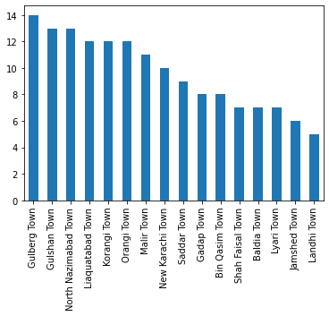

```python
df['count_towns'].plot(kind='bar')
```

### 3.3 - Clustering

```python
data_frame.head()
```

|  | town_name | union_name | latitude | longitude |
| --- | --- | --- | --- | --- |
| 8 | Ibrahim Hyderi | Baldia Town | 24.919 | 66.9877 |
| 9 | Rehri | Baldia Town | 24.919 | 66.9877 |
| 10 | Cattle Colony | Baldia Town | 24.919 | 66.9877 |
| 11 | Qaidabad | Baldia Town | 24.919 | 66.9877 |
| 12 | Landhi Colony | Baldia Town | 24.919 | 66.9877 |

```python
# set number of clusters
kclusters = 5

clustering = data_frame[['latitude','longitude']]

# run k-means clustering
kmeans = KMeans(n_clusters=kclusters, random_state=0).fit(clustering)

# check cluster labels generated for each row in the dataframe
kmeans.labels_[0:10]
```

```
array([3, 3, 3, 3, 3, 3, 3, 4, 4, 0])
```

```python
data_frame.insert(0, 'cluster_label', kmeans.labels_)
data_frame.head()
```

|  | cluster_label | town_name | union_name | latitude | longitude |
| --- | --- | --- | --- | --- | --- |
| 8 | 3 | Ibrahim Hyderi | Baldia Town | 24.919 | 66.9877 |
| 9 | 3 | Rehri | Baldia Town | 24.919 | 66.9877 |
| 10 | 3 | Cattle Colony | Baldia Town | 24.919 | 66.9877 |
| 11 | 3 | Qaidabad | Baldia Town | 24.919 | 66.9877 |
| 12 | 3 | Landhi Colony | Baldia Town | 24.919 | 66.9877 |

```python
# create map
map_clusters = folium.Map(location=[latitude, longitude], zoom_start=11)

# set color scheme for the clusters
x = np.arange(kclusters)
ys = [i + x + (i*x)**2 for i in range(kclusters)]
colors_array = cm.rainbow(np.linspace(0, 1, len(ys)))
rainbow = [colors.rgb2hex(i) for i in colors_array]

# add markers to the map
markers_colors = []
for lat, lon, poi, cluster in zip(data_frame['latitude'], data_frame['longitude'], data_frame['town_name'], data_frame['cluster_label']):
    label = folium.Popup(str(poi) + ' Cluster ' + str(cluster), parse_html=True)
    folium.CircleMarker(
        [lat, lon],
        radius=5,
        popup=label,
        color=rainbow[cluster-1],
        fill=True,
        fill_color=rainbow[cluster-1],
        fill_opacity=0.7).add_to(map_clusters)

map_clusters
```

[interactive chart not shown]

## 5. Conclusion

My boss had an *idea* and wanted to decide where she should start her *Dairy in Karachi*. She assigned me the job to analyze the data of Karachi and help her decide. After complete process through wrapping data and processing it for data that we need to analyze and after analysis we found an optimized location for her business and it's **"*Gulberg Town, Karachi*"**.